# Bayesian A/B Testing in R

Adam Rosenblit & David Denton

April 26, 2019

### This story is based on actual events. In certain cases, details, timelines, or characters may have been altered for statistical purposes.

### Company Overview

- Established in 2012
- Leading online widget supplier
- Excellent sales growth during first four years
- Sales began to decrease in 2016
  - Complicated web order form
  - Increasing number of orders from mobile devices

## Existing Sales Funnel

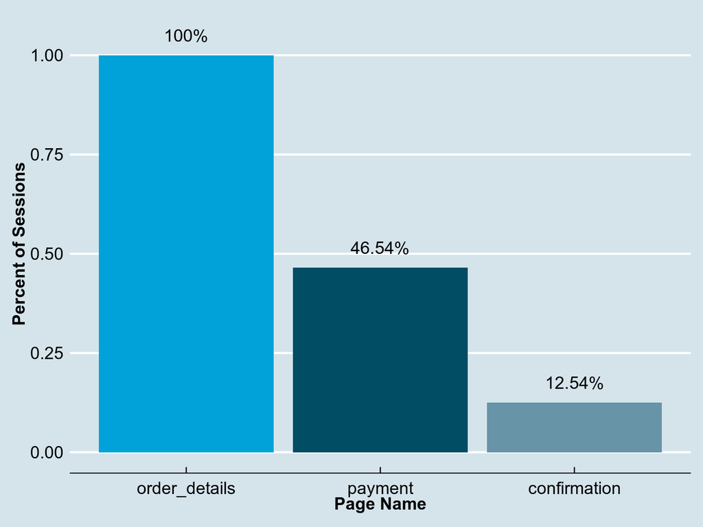

- The Problem
  - Conversion rate is low
  - Too many potential customers are lost
- The Solution
  - Develop a new buy-flow
  - Split site traffic between old & new buy-flows
  - Perform A/B test

## Sales Funnels During A/B Test

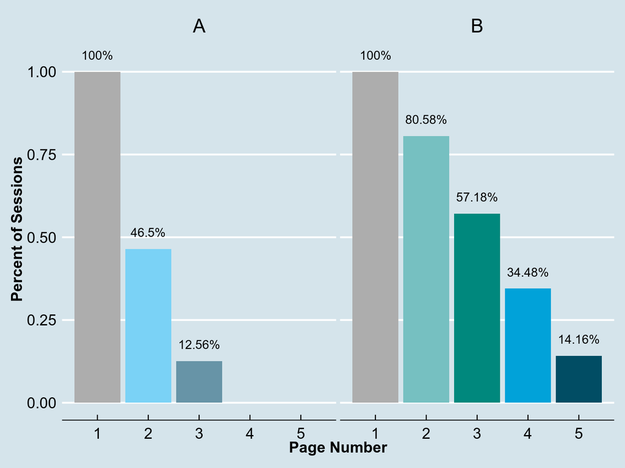

### Frequentist Approach

- Calcuate sample size using Power Test
- Calculate a point estimate of the conversion rate (sample proportion) for A and B
- Conduct test under the null hypothesis that the conversion rates are equal
- Hope that the resulting p-value < 0.05 so we can reject the null and therefore accept the alternative

### Bayesian Approach

- Encapsulate prior knowledge of conversion rate (ie, Find the conjugate prior distribution of the true parameter)
- Combine test data with prior knowledge to get the posterior distribution over the parameter
- Obtain direct probabilities of whether B is better than A (and by how much), and of the expected loss associated with choosing B over A

### Bayesian vs Frequentist Approach

- Instead of p-values you get direct probabilities on whether B is better than A (and by how much)
- Instead of point estimates your posterior distributions are parametrized random variables
- Bayesian tests are also immune to ‘peeking’ and are thus valid whenever a test is stopped

### So, how does the Bayes A/B test work?

- Find a conjugate prior for the parameter in question
  - Each visit is an *iid* Bernoulli(p) trial
  - Therefore, the set of visits are Binomial(n,p),
  - The conjugate prior of the parameter of a Binomial *RV* is the Beta Distribution
  - So, p ~ Beta($\alpha$$_{cp}$, $\beta$$_{cp}$)
  - Set $\alpha$$_{cp}$ = *conversions* and $\beta$$_{cp}$ = *drop-offs*

### A little intuition behind $\alpha$$_{cp}$ and $\beta$$_{cp}$

- $\widehat{p}$ = conversions / (conversions + drop_offs)
- E($\widehat{p}$) = p
- If p ~ Beta($\alpha, \beta$), then E(p) = $\alpha$ / ($\alpha$ + $\beta$)

### So, how does the Bayes A/B test work? (continued)

- Use data collected for A and B to define the posterior distributions over their parameters
  - $p_A$ ~ Beta($\alpha$$_A$ + $\alpha$$_{cp}$, $\beta$$_A$ + $\beta$$_{cp}$)
  - $p_B$ ~ Beta($\alpha$$_B$ + $\alpha$$_{cp}$, $\beta$$_B$ + $\beta$$_{cp}$)

### So, how does the Bayes A/B test work? (continued)

- Conduct a MonteCarlo simulation using those posterior distributions
  - Draw n samples from $p_A$ and from $p_B$
  - Calculate P(B>A)
  - Calculate credible interval on (B-A)/A
  - Calculate posterior expected loss associated with choosing B over A

### Before we jump into our Bayes Test, let’s run some hypothesis tests

## Frequentist A/B Test Results

```
##
##  2-sample test for equality of proportions with continuity
##  correction
##
## data:  c(pretest_A_stats$conversions, test_A_stats$conversions) out of c(pretest_A_stats$sample_size, test_A_stats$sample_size)
## X-squared = 1.1052e-29, df = 1, p-value = 1
## alternative hypothesis: two.sided
## 95 percent confidence interval:
##  -0.01338613  0.01298613
## sample estimates:
## prop 1 prop 2
## 0.1254 0.1256
```

```
##
##  2-sample test for equality of proportions with continuity
##  correction
##
## data:  c(test_A_stats$conversions, test_B_stats$conversions) out of c(test_A_stats$sample_size, test_B_stats$sample_size)
## X-squared = 5.3917, df = 1, p-value = 0.02023
## alternative hypothesis: two.sided
## 95 percent confidence interval:
##  -0.029532772 -0.002467228
## sample estimates:
## prop 1 prop 2
## 0.1256 0.1416
```

## Our Conjugate Prior

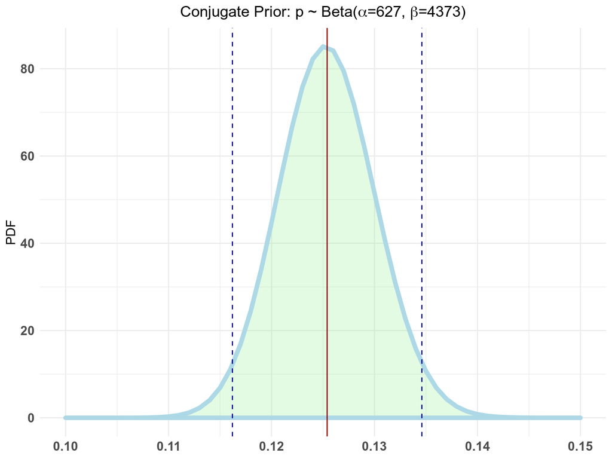

## Bayes A/B Test Plots

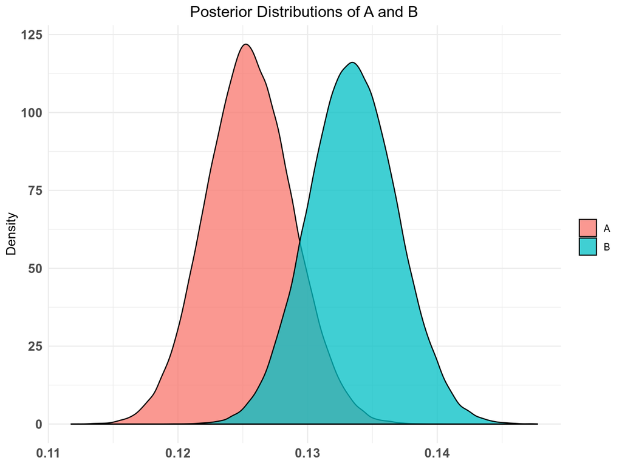

## Bayes A/B Test Plots, continued

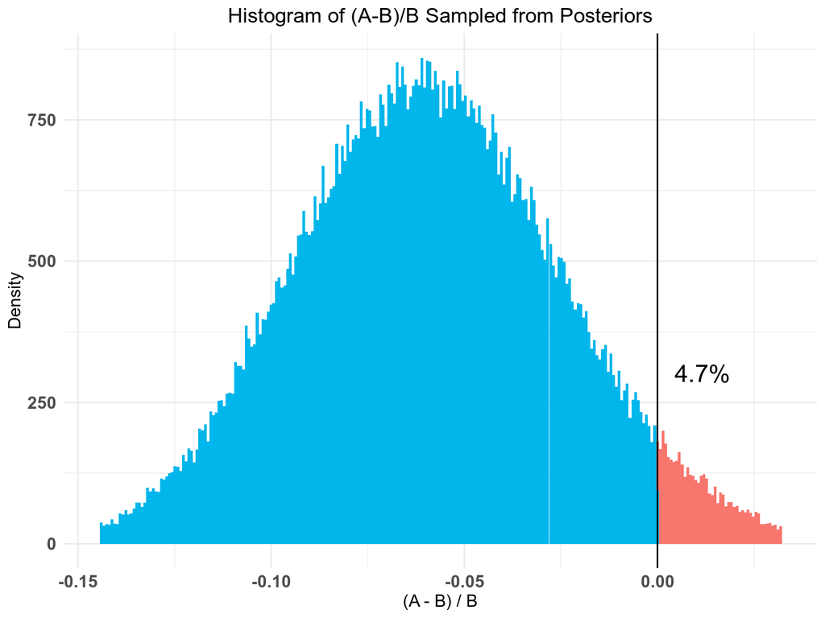

## Bayes A/B Test Summary

```
## Quantiles of posteriors for A and B:
##
## $Probability
## $Probability$A
##        0%       25%       50%       75%      100%
## 0.1117591 0.1232505 0.1254625 0.1277291 0.1401820
##
## $Probability$B
##        0%       25%       50%       75%      100%
## 0.1194867 0.1311690 0.1334634 0.1357881 0.1477284
##
##
## --------------------------------------------
##
## P(A > B) by (0)%:
##
## $Probability
## [1] 0.04694
##
## --------------------------------------------
##
## Credible Interval on (A - B) / B for interval length(s) (0.9) :
##
## $Probability
##           5%          95%
## -0.114863580 -0.001075548
##
## --------------------------------------------
##
## Posterior Expected Loss for choosing B over A:
##
## $Probability
## [1] 0.06504834
```

### bayesAB can do so much more!

- We could also compare user interactions on two versions of a page
  - interactions ~ Poisson($\lambda$)
  - then, $\lambda$ ~ Gamma($\alpha, \beta$)
- Then we could test the effect of increased/decreased interactions on conversion using the `combine` function

### Further Readings

- https://cran.r-project.org/web/packages/bayesAB/vignettes/introduction.html
- https://github.com/FrankPortman/bayesAB/
- https://www.countbayesie.com/blog/2015/2/18/hans-solo-and-bayesian-priors
- https://www.countbayesie.com/blog/2015/4/25/bayesian-ab-testing
- http://varianceexplained.org/r/bayesian_ab_baseball/

### Github repo

https://github.com/adamrosenblit/usm_adms

### Slide presentation

https://fishingwithdave.net/usm/